# Block Bootstrap

I will demonstrate how to do block bootstrap using **Xy** dataset from ISLR’s practice questions in the chapter 5.

## Load Data

```r
Xy <- get(load(here("data/5.R.RData")))
```

# Let’s Explore Data

Data Frame `Xy` has 3 numeric variables

```r
str( Xy)
```

```
'data.frame':   1000 obs. of  3 variables:
 $ X1: num  1.3 1.27 1.24 1.21 1.18 ...
 $ X2: num  0.806 0.799 0.792 0.785 0.778 ...
 $ y : num  0.299 0.318 0.337 0.356 0.375 ...
```

```r
summary(Xy)
```

```
       X1                X2                y
 Min.   :-0.8068   Min.   :-1.1753   Min.   :-0.75293
 1st Qu.:-0.1674   1st Qu.:-0.2339   1st Qu.:-0.06136
 Median : 0.2798   Median : 0.1824   Median : 0.30452
 Mean   : 0.3337   Mean   : 0.1288   Mean   : 0.35471
 3rd Qu.: 0.7017   3rd Qu.: 0.4646   3rd Qu.: 0.73283
 Max.   : 1.8531   Max.   : 1.7658   Max.   : 2.03922
```

# Fit Linear Model

Supposed we want to fit a linear regression model of `y` on `X1` and `X2`.

### Q1: What is the standard error for coefficients of X2 or ($\beta_2$) ?

```r
Xy_lm.fit <- lm(y ~ X1 + X2, data = Xy)

summary(Xy_lm.fit)
```

```
Call:
lm(formula = y ~ X1 + X2, data = Xy)

Residuals:
     Min       1Q   Median       3Q      Max
-1.44171 -0.25468 -0.01736  0.33081  1.45860

Coefficients:
            Estimate Std. Error t value Pr(>|t|)
(Intercept)  0.26583    0.01988  13.372  < 2e-16 ***
X1           0.14533    0.02593   5.604 2.71e-08 ***
X2           0.31337    0.02923  10.722  < 2e-16 ***
---
Signif. codes:  0 ‘***’ 0.001 ‘**’ 0.01 ‘*’ 0.05 ‘.’ 0.1 ‘ ’ 1

Residual standard error: 0.5451 on 997 degrees of freedom
Multiple R-squared:  0.1171,    Adjusted R-squared:  0.1154
F-statistic: 66.14 on 2 and 997 DF,  p-value: < 2.2e-16
```

As you can see that $S.E.$ of $\beta_2$ was 0.0292267

### Helper function

Write a helper function to shuffles rows of `Xy`, fits the Linear model and return $\beta_2$.

```r
Xy_lm_boot_fn <- function(data, index){

  lm_coef <- coef(lm(y ~ X1 + X2, data = data, subset = index))
  lm_coef["X2"]

}
```

Let’s test the first iteration of the bootstapped $\beta_2$.

```r
set.seed(123)

index1 <- sample(1000, 1000, replace = TRUE)
index2 <- sample(1000, 1000, replace = TRUE)

Xy_lm_boot_fn(Xy, index1)
```

```
       X2
0.3113108
```

```r
Xy_lm_boot_fn(Xy, index2)
```

```
      X2
0.324674
```

OK, It works!

# Regular Bootstrap

I will use `{boot}` package to compute bootstrap of 1000 replicates using `Xy_lm_boot_fn()` as `statistic` argument in `boot()`.

```r
library(boot)
```

```r
Xy_lm_boot
```

```
ORDINARY NONPARAMETRIC BOOTSTRAP


Call:
boot(data = Xy, statistic = Xy_lm_boot_fn, R = 1000)


Bootstrap Statistics :
    original        bias    std. error
t1* 0.313367 -0.0001527919  0.03539184
```

The $S.E.$ of the bootstapped $\beta_2$ is 0.0353918

# Auto-Correlation

**Why we need to do block bootstrap ?**

Let’s see plots of observation in x-axis and each variables in y-axis. I will use `{ggplot2}` to do this.

First I need to add rownames to column and pivot to long format.

```r
Xy_to_long <- function(data) {
  data %>%
    tibble::rownames_to_column("Observations") %>%
    dplyr::mutate(Observations = as.numeric(Observations)) %>%
    tidyr::pivot_longer(cols = X1:y, names_to = "Variables", values_to = "Values") %>%
    dplyr::mutate(Variables = factor(Variables, levels = c( "y", "X1", "X2")))

}
```

```r
Xy_long <- Xy_to_long(Xy)
head(Xy_long)
```

| Observations | Variables | Values |
| --- | --- | --- |
| 1 | X1 | 1.2977198 |
| 1 | X2 | 0.8059212 |
| 1 | y | 0.2989683 |
| 2 | X1 | 1.2673235 |
| 2 | X2 | 0.7990341 |
| 2 | y | 0.3181337 |

And then plot using `geom_line`:

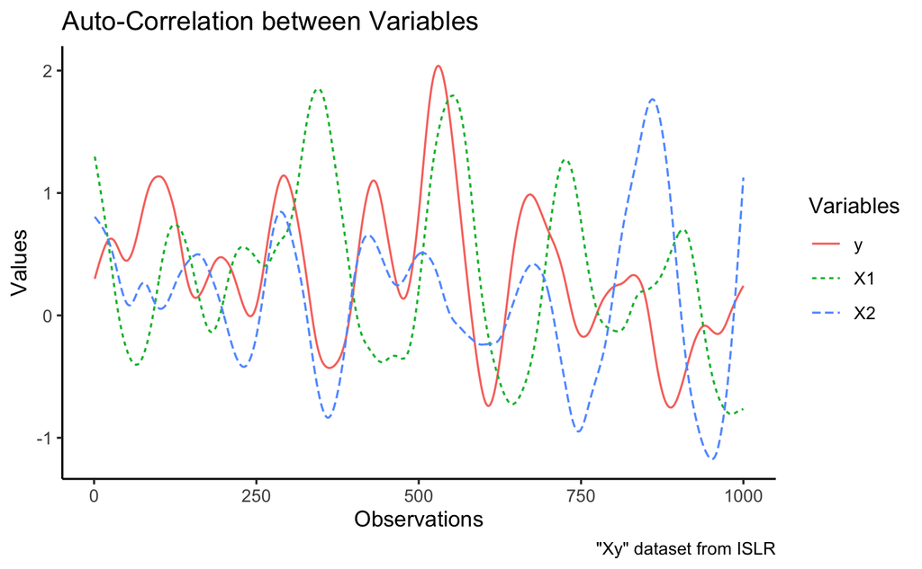

```r
Xy_long %>%
  ggplot(aes(Observations, Values, color = Variables, linetype = Variables)) +
  geom_line(aes(group = Variables)) +
  labs(title = "Auto-Correlation between Variables",
       caption = "\"Xy\" dataset from ISLR")
```

(You can also do the same thing by using base R plot by `matplot(Xy,type="l")` as in ISLR’s example.)

From this plot, It can be seen that there are correlation between observations (rows). A given data point (e.g. $(X1_i, X2_i, Y_i)$) would influence the value of next data points (e.g. $(X1_{i+1}, X2_{i+1}, Y_{i+1})$). This is called auto-correlation.

Thus, using regular bootstap might rearrange the consecutive rows that are correlated and modify the result.

**Let’s plot observation vs values after bootstapped.**

```r
set.seed(123)
index1 <- sample(1000, 1000, replace = TRUE)

Xy_row_shuffle1 <- Xy[index1, ]
rownames(Xy_row_shuffle1) <- 1:1000
```

[output not shown]

[output cut: 990 more lines]